# Workshop 8 - Data Visualisation I

Elisabeth Busch-Nentwich

## 1. Introduction

Well done on all your hard work on tidying messy data. This week we’re starting to reap the rewards by producing our first plots. By the end of this workshop you’ll be able to distinguish which ggplot2 tools to use to plot categorical and continuous data, manipulate how the data are displayed and add plot and axis titles.

## 2. The Grammar of Graphics

ggplot2 follows the principle of the “The Grammar of Graphics” by Wilkinson, Anand, and Grossman (2005). In a nutshell, a graphic such as a scatter plot gets dissected into its components, so that we can manipulate each component separately:

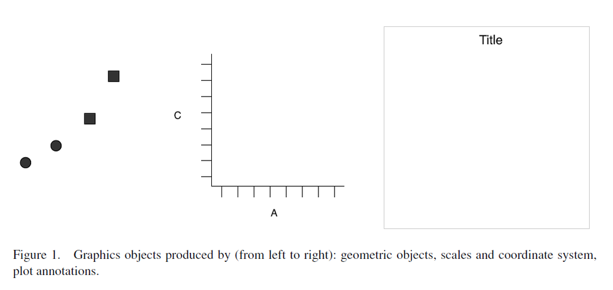

*From A Layered Grammar of Graphics by Hadley Wickham*

The geometric objects that display our data are called **geoms**, e.g. `geom_point`. Each geom has features, which are called **aesthetics** in ggplot. These features are their position along the x- and y-axis, their shape, size and colour.

Now the important bit: To visualise our data we **map** variables of our data to those aesthetics. And this is why we want our data tidy, i.e. one variable per column, so that we can easily say which variable we want displayed through which aesthetic.

In addition, we can determine the coordinate system (in most cases Cartesian, i.e. x- and y-axes, but there are others, too), scales (on axes, but also for example when we use colour), and plot annotations.

Let’s start by looking at some examples. For this we’ll use a puppy-equivalent of a dataset called Palmer Penguins.

```r
install.packages("palmerpenguins")
library(palmerpenguins)
library(tidyverse)
```

**Have a look at the `penguins` dataframe with your favourite looking-at-datasets function.**

The dataframe has a number of different measurements for three penguin species across three different islands.

Let’s say we want to find out whether there is a correlation between body mass and bill length. A simple scatterplot is a good way to look at correlations between two continuous variables.

To do this, we need to tell ggplot which **data** we’re looking at, which **geom** we’d like to use, and which **variables** we’d like to **map** to which **aesthetics**.

**Have a look at the code below and identify the bits that are high-lighted in bold.**

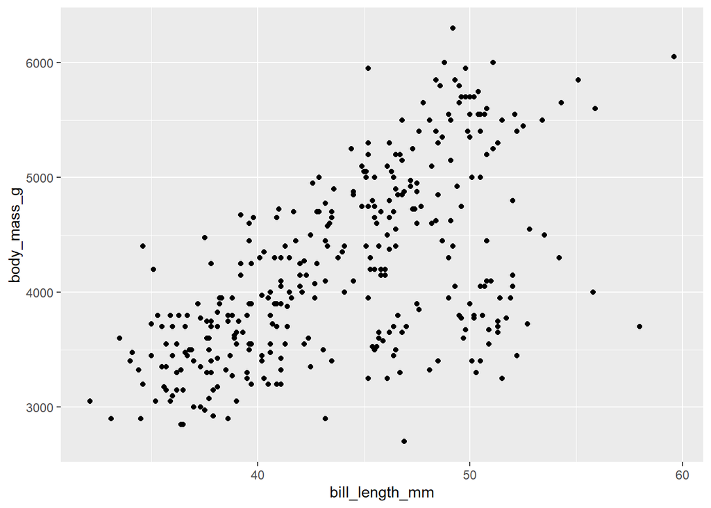

```r
ggplot(data = penguins) +
  geom_point(mapping = aes(x = bill_length_mm, y = body_mass_g))
```

So there seems to be a correlation, but there is also what looks like a cluster that is shifted towards the bottom right of the graph. Could those be species differences? Let’s check by mapping `species` to the aesthetic `colour` of `geom_point`:

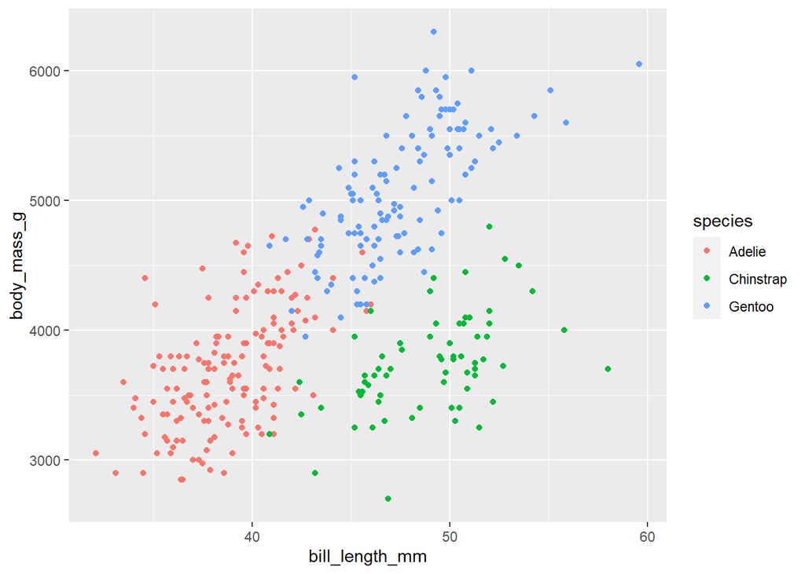

```r
ggplot(data = penguins) +
  geom_point(mapping = aes(x = bill_length_mm, y = body_mass_g, colour = species))
```

**Does this cluster also correlate with the island the penguins are from? Copy and change the code above to check.**

We can add additional layers to our plot by specifying additional geoms.

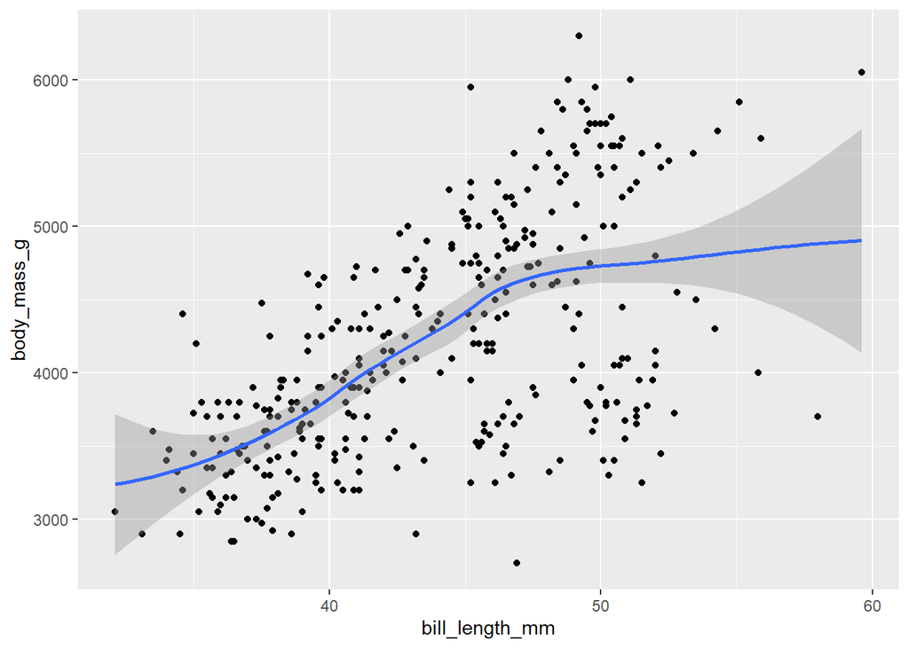

```r
ggplot(data = penguins) +
  geom_point(mapping = aes(x = bill_length_mm, y = body_mass_g)) +
  geom_smooth(mapping = aes(x = bill_length_mm, y = body_mass_g))
```

There are several things we can do to improve this code and plot. Firstly, we don’t have to repeat the mapping of variables if we use the same ones in different layers. We can pass them to `ggplot()` which means that they will be inherited by the geoms that follow:

```r
ggplot(data = penguins, mapping = aes(x = bill_length_mm, y = body_mass_g)) +
  geom_point() +
  geom_smooth()
```

Secondly, we already know that our data fall into three species clusters, so fitting the curve across all three is probably not a great idea. Let’s map species again to `colour`.

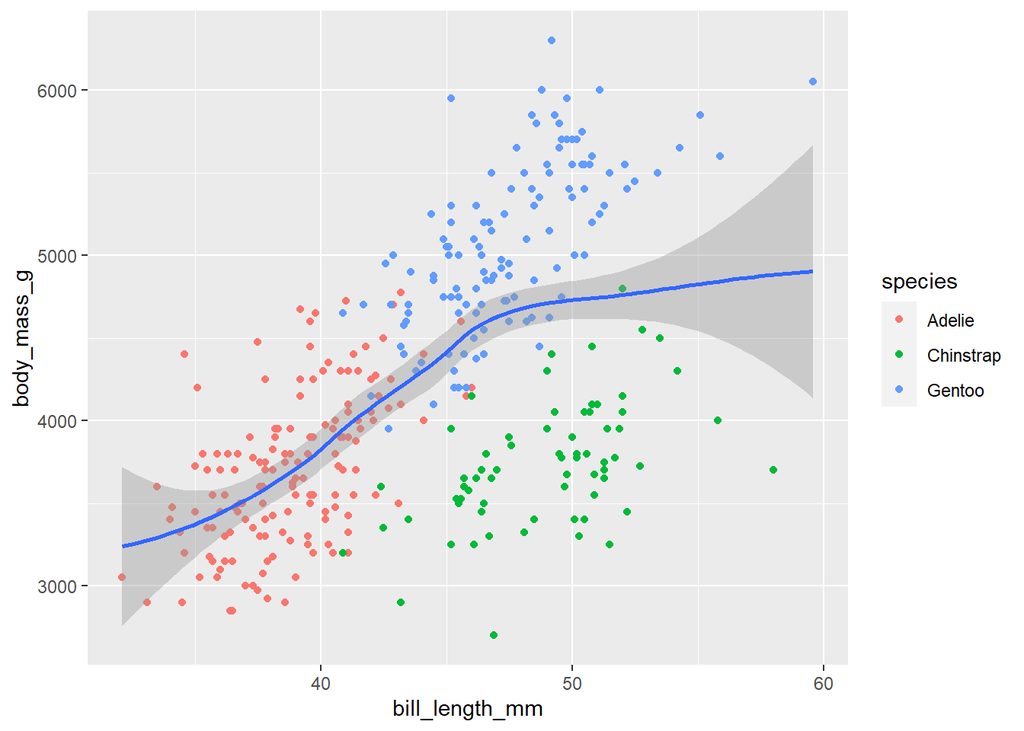

```r
ggplot(data = penguins, mapping = aes(x = bill_length_mm, y = body_mass_g)) +
  geom_point(mapping = aes(colour = species)) +
  geom_smooth()
```

Huh, the curve is still going across all three species. That’s because mappings are only inherited from `ggplot()`, not between geoms.

**Copy and fix the code above, so that each species has its own fitted curve.**

Once we’re happy with our plot we can assign it to a variable and add other layers later. This way we can save a basic plot and try out different layers or other modifications.

```r
pengu_plot <-
  ggplot(data = penguins,
         mapping = aes(x = bill_length_mm, y = body_mass_g)) +
  geom_point(aes(colour = species))

#We can add layers to our plot
pengu_plot +
  geom_smooth()
```

**Write code to produce the following plot. Hint: Look at the documentation for `geom_smooth` to find the arguments you need for a linear model and to remove the confidence intervals.**

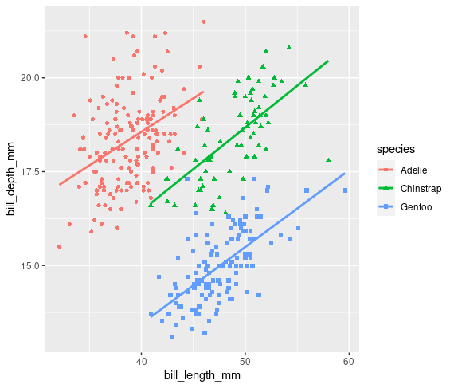

## 3. Saving plots

We can save our plots to a file using ‘ggsave’. We can either give ggsave a plot variable:

```r
ggsave(filename = "penguin_plot_1.png", plot = pengu_plot)
```

Or if we don’t pass it a variable it will save the last plot we printed to screen

```r
pengu_plot +
  geom_smooth()

ggsave("penguin_plot_2.png")
```

ggsave gives you a lot of flexibility in how you save your files; there’s too many to go into in detail here, but you can start by changing the dimensions of your plot.

**Look at the documentation for ggsave; save your latest plot with the linear model lines as a 200mm x 300mm png.**

## 4. Continuous versus categorical variables

So far we have only mapped continuous variables such as length measurements to our x- and y-positions. We have mapped categorical variables, such as species or island, to shape or colour of our geoms. Which geom we need to use depends on the type of variable we’d like to map to the x- and y-coordinates. For example, if we’d like to investigate body_mass for each species, we can use box plots.

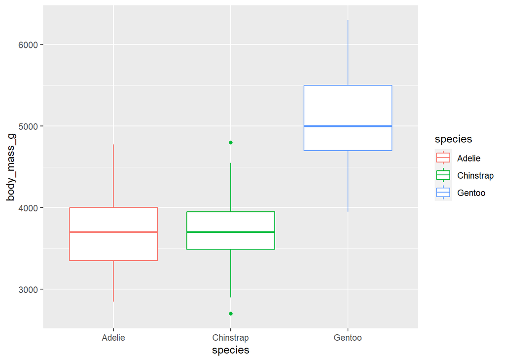

```r
ggplot(data = penguins,
       mapping = aes(x = species, y = body_mass_g)) +
  geom_boxplot(mapping = aes(colour = species))
```

Notice how mapping `species` to `colour` in `geom_boxplot()` only changes the colour of the lines.

**Change the code, so that it fills the boxes with colour instead of the lines. You might have to google how to do that - it’s not obvious from the documentation.**

We often want to determine the order in which we display our data. This is where **factors** come in handy. Categorical variables that have a defined and known set of values, for example the three species in `penguins`, can be defined as factors. Factors have **levels** which are essentially rank positions for each unique value. By default, levels are in alphanumerical order, that’s why the three species appear in alphabetical order in the above plot.

**Look at `penguins` using both `head()` and `str()`. Where can you see which variables are factors? What additional information does str() show you?**

Here is an example where alphabetical order would be annoying:

```r
df_days <-
  data.frame(day = c("Mon", "Tues", "Wed", "Thu"),
             counts = c(3, 8, 10, 5))
df_days$day <- as.factor(df_days$day)
str(df_days)
```

```
## 'data.frame':    4 obs. of  2 variables:
##  $ day   : Factor w/ 4 levels "Mon","Thu","Tues",..: 1 3 4 2
##  $ counts: num  3 8 10 5
```

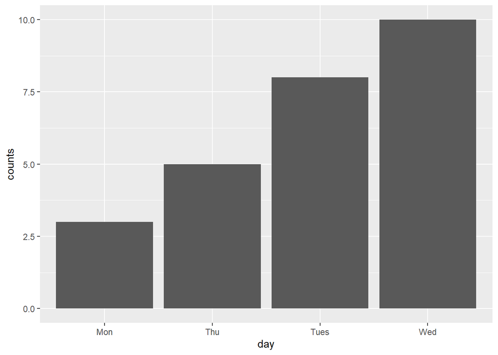

```r
ggplot(data = df_days, mapping = aes(x = day, y = counts)) +
  geom_col()
```

Luckily we can change that very easily:

```r
df_days$day <- factor(df_days$day, levels = c("Mon", "Tues", "Wed", "Thu"))
str(df_days)
```

```
## 'data.frame':    4 obs. of  2 variables:
##  $ day   : Factor w/ 4 levels "Mon","Tues","Wed",..: 1 2 3 4
##  $ counts: num  3 8 10 5
```

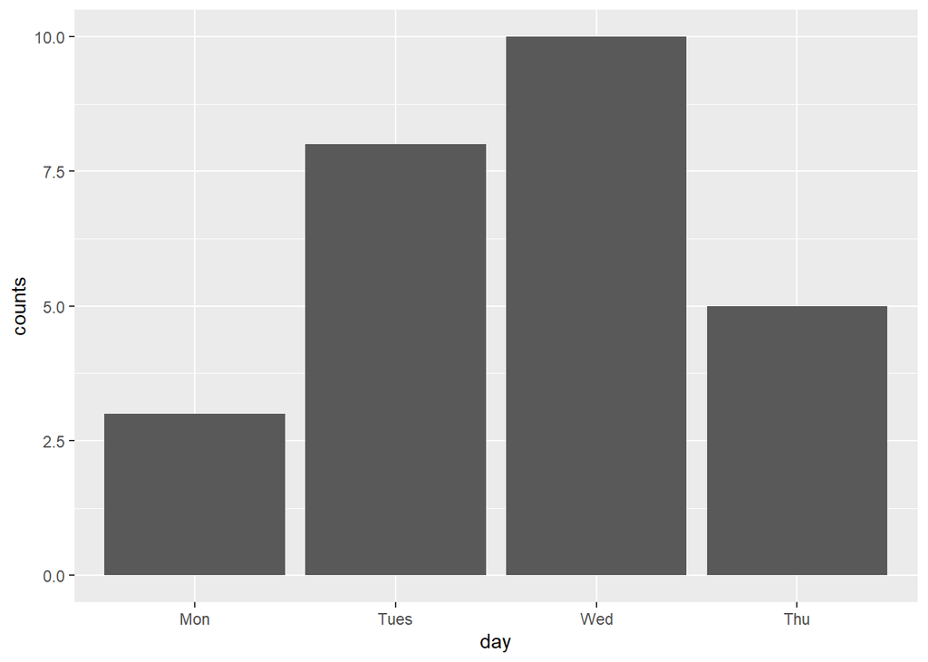

```r
ggplot(data = df_days, mapping = aes(x = day, y = counts)) +
  geom_col()
```

Let’s put together a few of the things you’ve learnt so far:

**Write the code to reproduce this plot. You’ll have to use the data visualisation cheat sheet to find the correct geom.**

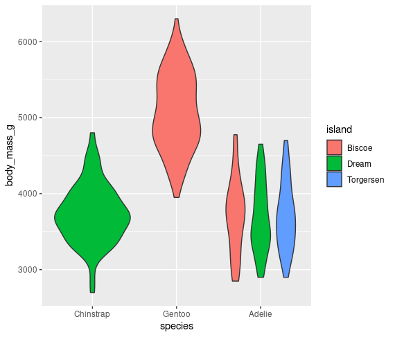

## 5. Statistical transformations

A lot of geoms do statistical transformations, i.e. calculations of counts, means, etc., by default. You’ve actually already seen that in the boxplot graphs! Our dataframe does not contain the median, 25th percentile, 75th percentile, etc. for body_mass_g, but the geom calculates that. Here is another example:

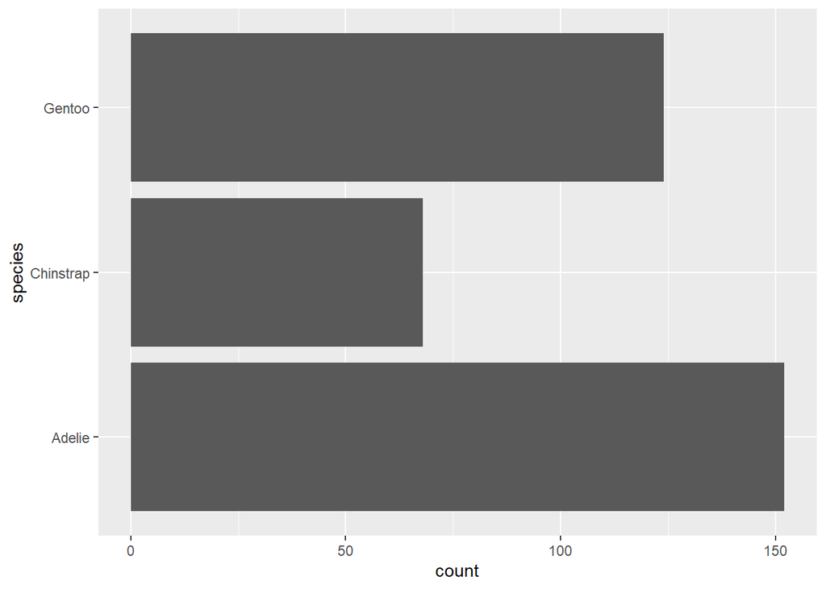

```r
ggplot(data = penguins) +
  geom_bar(mapping = aes(x = species)) +
  coord_flip()
```

Our dataframe does not contain the counts of penguins for each species. `geom_bar()` calculates those.

**Have a look at the documentation for `geom_bar`. What is the difference between `geom_bar()` and `geom_col()`? Also, what does `coord_flip()` do?**

**Have a close look at the plots below. What is the difference? Can you find the geom to reproduce these plots and the geom argument to switch between the two? Bonus credit: The bars are slightly transparent. Can you find the argument to change transparency?**

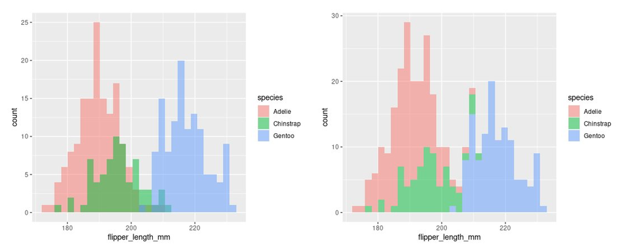

## 6. Plotting only a subset of your data: filter()

We often want to plot a subset of our data. For example, you may want to look at penguins of two of the species only. This is where the dplyr function `filter()` comes in. It does what it says on the tin: It filters (or subsets) rows based on a logical evaluation you give it.

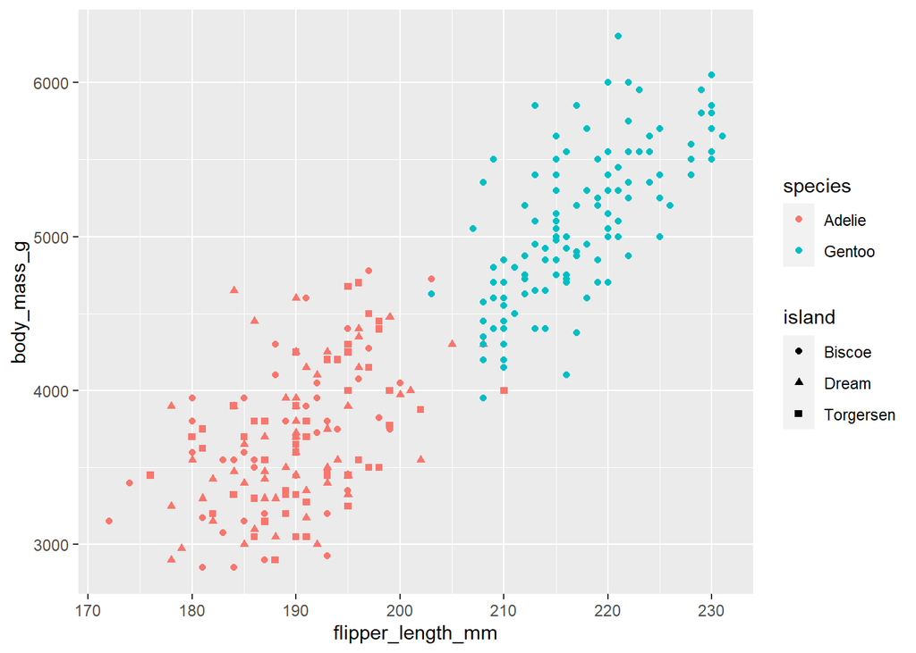

```r
penguins %>% filter(!species == "Chinstrap") %>%
  ggplot(mapping = aes(x = flipper_length_mm, y = body_mass_g)) +
  geom_point(mapping = aes(colour = species, shape = island))
```

Notice in the code above how we switch from the pipe operator `%>%` to a `+` sign for adding layers to `ggplot()`. Mixing those up is quite a common error. We also don’t need to tell `ggplot()` which data to use because we have piped the dataset into `ggplot()` already.

`filter()` is extremely useful together with the function `is.na()` to get rid of pesky NAs.

**Use `is.na(sex)` with `filter()` to reproduce the plot below, so that it only contains penguins where sex is known.**

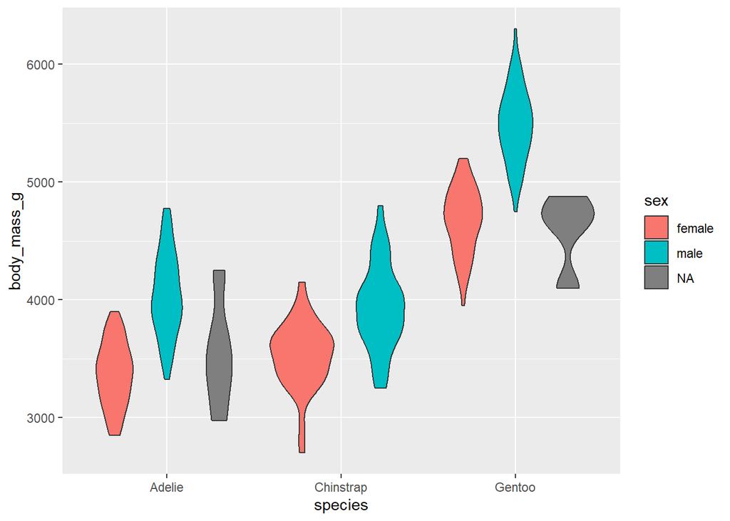

Another very useful function is `arrange()` which allows you to sort rows by values in one or more columns. You will need this for the last exercise of the workshop. It’s easy to use, so we’ll leave that to you to figure out when you need it.

## 7. Labels

So far we have only manipulated the geometric objects and the axes. Here we’ll make a start on making our plot prettier by editing the labels (much more on jazzing up plots next week). The function to manipulate or add labels is `labs()`.

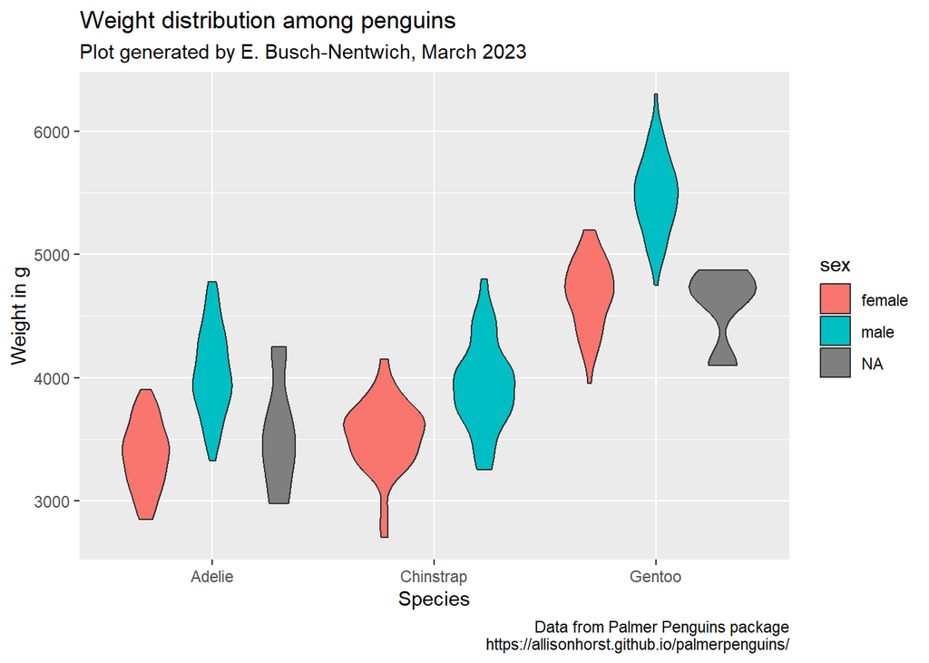

```r
penguins %>%
  ggplot(mapping = aes(x = species, y = body_mass_g)) +
  geom_violin(aes(fill = sex)) +
  labs(title = "Weight distribution among penguins",
       subtitle = "Plot generated by E. Busch-Nentwich, March 2023",
       x = "Species",
       y = "Weight in g",
       caption = "Data from Palmer Penguins package\nhttps://allisonhorst.github.io/palmerpenguins/"
       )
```

Changing the legend labels can’t be done within `labs()`, because the legend is part of scales. Which function we need to use depends on the aesthetics and variables. Here we have mapped a categorical, i.e. discrete, variable (sex) to `fill`, so the function to use is `scale_fill_discrete()`. This function also allows you to change the colours, but we’ll talk about colours a lot more over the next couple of weeks.

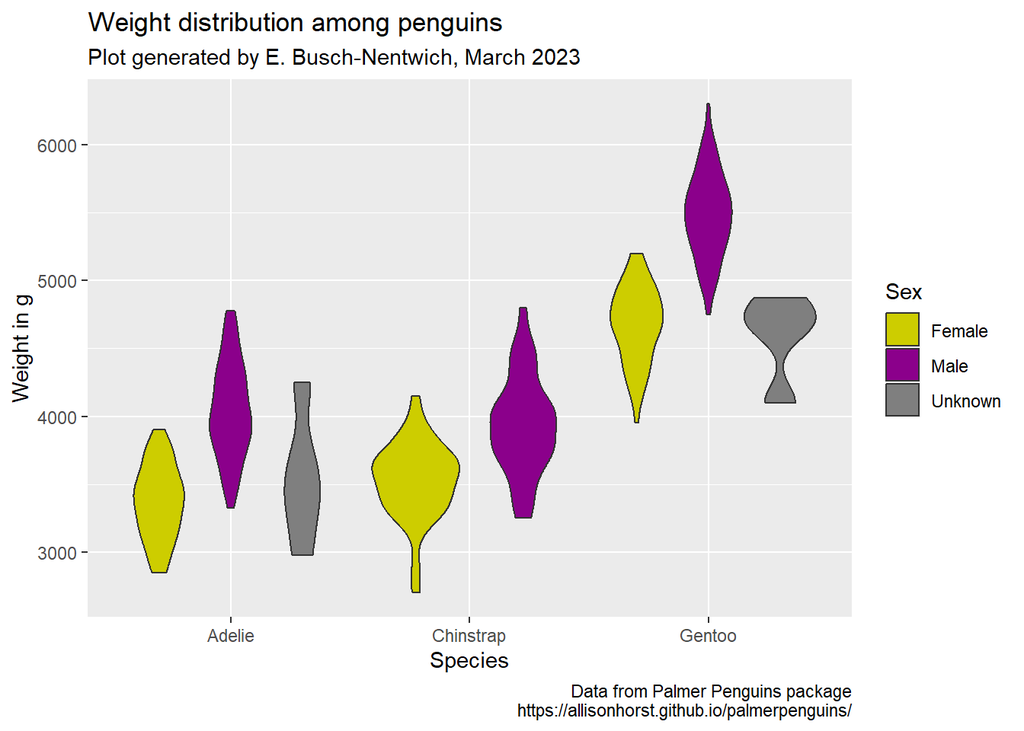

```r
penguins %>%
  ggplot(mapping = aes(x = species, y = body_mass_g)) +
  geom_violin(aes(fill = sex)) +
  labs(title = "Weight distribution among penguins",
       subtitle = "Plot generated by E. Busch-Nentwich, March 2023",
       x = "Species",
       y = "Weight in g",
       caption = "Data from Palmer Penguins package\nhttps://allisonhorst.github.io/palmerpenguins/"
       ) +
  scale_fill_discrete(name = "Sex",
                      labels = c("Female", "Male", "Unknown"),
                      type = c("yellow3", "magenta4", "grey"))
```

**Generate a new plot from the penguin data with at least two geoms, good labels, and maybe even try out some colours. For example, you could try and find a geom that allows you to show the individual datapoints on top of boxplots. Go wild!**

## 8. The big challenge

We’re going to revisit the World Malaria Report, though this time we’re looking at modelling data. Fortunately this dataset is already tidy, so you can read it in as it is.

**Read in the modelling table (“wmr_modelling.txt”) and reproduce the following plot. You’ll have to figure out a way to order the dataframe by deaths and then convince ggplot to keep the data in that order when plotting (hint: factors are your friends!).**

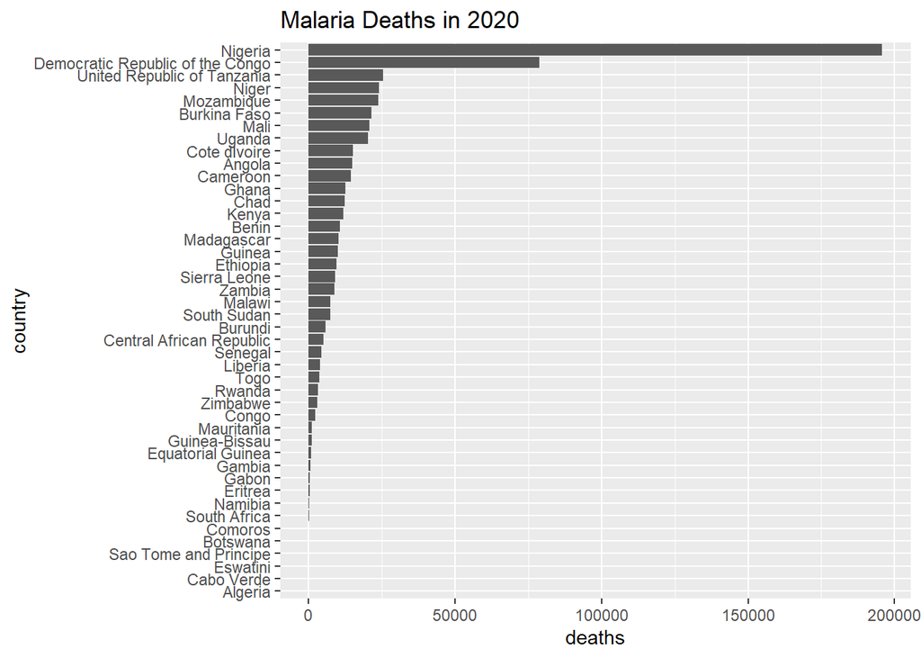